# Leasing vs. kontant- og lånefinansieret køb — totaløkonomi

TCO pr. år med alternativomkostning, holdeperiode og ekstra-km

06 September 2026

## Idéen

Vi sammenligner tre måder at få en fabriksny elbil på, målt som **totale ejeromkostninger pr. år (TCO)**:

- **Kontantkøb** — hele prisen betales nu; du bærer værditabet, men får restværdien.
- **Lånefinansieret køb** — 20,0 % udbetaling, resten lånt (5,5 % rente, 7 år, rentefradrag 33,0 %). Du binder mindre kapital, men betaler rente.
- **Privatleasing** — kontraktfast pris, ingen restværdirisiko, men du ejer intet.

Det centrale er **alternativomkostningen**: kapital bundet i bilen kunne have været investeret. Vi diskonterer derfor alle betalinger med renten `k` (som *er* alternativomkostningen) og omregner til en **ækvivalent årlig omkostning (EAC)**. To scenarier, efter skat: **risikofri 1,6 %** og **risikobehæftet 5,1 %**.

Alle beløb er **nominelle** med 2,0 % inflation. Vi diskonterer med det nominelle *afkast* (`k`), ikke med inflationen — det svarer matematisk til en realrente-beregning (se metoden nederst). De reale renter — for risikofri **negativ** — står i antagelserne.

## Antagelser og parametre

[output not shown]

Rå input-parametre pr. bil (rediger i leasing_vs_kontant_input.csv):

| Parameter | Enhed | Skoda_Enyaq_85 | VW_ID4_Pro | Peugeot_e3008 | Subaru_E_Outback | Toyota_bZ4X_Touring | Citroen_eC3 | Kategori |
| --- | --- | --- | --- | --- | --- | --- | --- | --- |
| Maerke | navn | Skoda | VW | Peugeot | Subaru | Toyota | Citroën | faelles |
| Kontantpris | kr | 374.995 | 339.995 | 289.990 | 369.900 | 369.990 | 169.990 | kontant |
| Batteri_kWh | kWh | 77 | 79 | 73 | 74,7 | 74,7 | 44 | faelles |
| Raekkevidde | km | 525 | 570 | 525 | 526 | 528 | 320 | faelles |
| Leasing_maaned | kr | 3.950 | 4.200 | 4.300 | 6.100 | 4.300 | 2.295 | leasing |
| Leasing_foerstegangsydelse | kr | 29.995 | 45.000 | 14.995 | 19.995 | 19.995 | 49.995 | leasing |
| Leasing_periode_mdr | mdr | 48 | 48 | 48 | 36 | 36 | 36 | leasing |
| Leasing_inkl_km_aar | km | 20.000 | 20.000 | 20.000 | 20.000 | 20.000 | 20.000 | leasing |
| Leasing_ekstra_km | kr_km | 1 | 1 | 1 | 1 | 1 | 1 | leasing |
| Leasing_oprettelse | kr | 0 | 0 | 0 | 0 | 0 | 0 | leasing |
| Leasing_aflevering | kr | 3.500 | 3.500 | 3.500 | 1.150 | 3.500 | 3.500 | leasing |
| Leasing_inkl_service | 0_1 | 1 | 1 | 1 | 1 | 1 | 1 | leasing |
| Leasing_inkl_ejerafgift | 0_1 | 0 | 0 | 0 | 0 | 0 | 0 | leasing |
| Leasing_inkl_forsikring | 0_1 | 0 | 0 | 0 | 0 | 0 | 0 | leasing |
| Ejerafgift_aar | kr | 1.500 | 1.500 | 1.500 | 1.500 | 1.500 | 1.200 | drift |
| Forsikring_aar | kr | 8.000 | 8.000 | 8.500 | 9.000 | 9.000 | 5.500 | drift |
| Service_lille | kr | 2.200 | 2.200 | 2.100 | 2.411,2 | 2.495 | 1.600 | drift |
| Service_stor | kr | 3.100 | 3.100 | 3.000 | 3.366,5 | 3.495 | 2.300 | drift |
| Service_interval_km | km | 30.000 | 30.000 | 25.000 | 15.000 | 15.000 | 25.000 | drift |
| Service_transport | kr | 0 | 0 | 0 | 0 | 100 | 0 | drift |
| Service_kilde | tekst | skøn | skøn | skøn | sourced | sourced | skøn | faelles |
| Daek_aar | kr | 3.000 | 3.000 | 3.000 | 3.500 | 3.500 | 2.000 | drift |
| Garanti_aar | aar | 5 | 5 | 8 | 10 | 10 | 8 | drift |
| Afskrivning_manuel | pct | — | — | — | — | — | — | faelles |

## Resultat: TCO pr. år

20,0 %-lånet ligger mellem kontant og leasing på bunden kapital. **Leasingfaktor** = årlig direkte leasingomkostning ÷ kontantpris. **Forskel** er positiv, når en løsning er dyrere end kontantkøb. **Break-even** er det alternativafkast, hvor leasing = kontant.

*(Afskrivning er slået til — kan slås fra i kontrolpanelet med MED_AFSKRIVNING <- FALSE.)*

| Parameter | Skoda_Enyaq_85 | VW_ID4_Pro | Peugeot_e3008 | Subaru_E_Outback | Toyota_bZ4X_Touring | Citroen_eC3 |
| --- | --- | --- | --- | --- | --- | --- |
| Kontantpris (kr) | 374.995 | 339.995 | 289.990 | 369.900 | 369.990 | 169.990 |
| Afskrivning (%/år, empirisk) | 11,5 % | 18,3 % | 11,3 % | 10,6 % | 6,8 % | 7,1 % |
| — 95 %-interval | 9,4 %–13,5 % | 16,4 %–20,2 % | 7,6 %–14,8 % | 1,8 %–18,6 % | 3,6 %–10,0 % | 4,2 %–9,8 % |
| Restværdi efter 8 år (kr) | 128.008 | 65.901 | 100.294 | 134.829 | 180.431 | 81.439 |
| Værditab i alt (kr) | 246.987 | 274.094 | 189.696 | 235.071 | 189.559 | 88.551 |
| Leasingfaktor (direkte/år ÷ pris) | 14,9 % | 18,4 % | 19,4 % | 21,7 % | 16,1 % | 26,7 % |
| Scenarie 1 — risikofri 1,6 % efter skat |  |  |  |  |  |  |
| TCO/år, kontant (kr) | 60.884 | 63.063 | 51.304 | 61.116 | 55.997 | 32.241 |
| TCO/år, lånekøb (kr) | 64.292 | 66.153 | 53.940 | 64.478 | 59.360 | 33.785 |
| TCO/år, leasing (kr) | 80.319 | 87.019 | 80.718 | 108.911 | 86.790 | 66.246 |
| Forskel/år (leasing − kontant) | 19.435 | 23.956 | 29.414 | 47.795 | 30.793 | 34.006 |
| Forskel/år (lån − kontant) | 3.408 | 3.090 | 2.635 | 3.362 | 3.363 | 1.545 |
| Scenarie 2 — risikobehæftet 5,1 % efter skat |  |  |  |  |  |  |
| TCO/år, kontant (kr) | 70.442 | 71.007 | 58.821 | 70.813 | 66.332 | 36.946 |
| TCO/år, lånekøb (kr) | 68.031 | 68.822 | 56.957 | 68.435 | 63.954 | 35.853 |
| TCO/år, leasing (kr) | 80.747 | 87.785 | 80.791 | 108.954 | 86.895 | 67.200 |
| Forskel/år (leasing − kontant) | 10.306 | 16.778 | 21.970 | 38.141 | 20.563 | 30.254 |
| Forskel/år (lån − kontant) | -2.410 | -2.185 | -1.864 | -2.378 | -2.378 | -1.093 |
| Beslutningsmål |  |  |  |  |  |  |
| Break-even afkast (leasing = kontant) | 8,9 % | 12,7 % | 14,9 % | 18,1 % | 12,0 % | 31,2 % |

## Værditab er den store ubekendt

Kun ejeren (kontant/lån) bærer værditabet; leasingprisen er kontraktfast. Afskrivning løber ud ad x-aksen, TCO/år op ad y-aksen. Blåt bånd = kontant, orange = leasing; båndbredden spænder fra risikofri til risikobehæftet rente. Lodret streg = bilens empiriske afskrivning. Hvor båndene krydser, vender regnestykket.

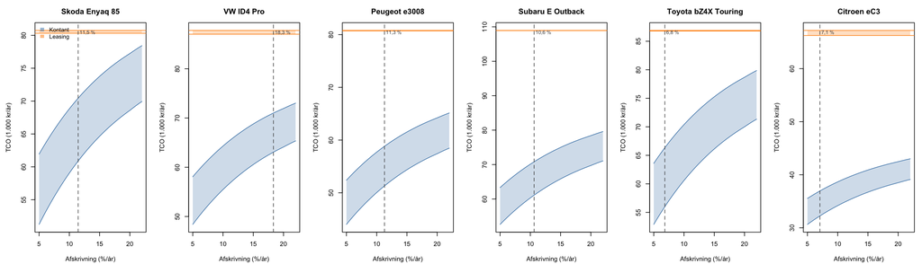

## Hvor meget hænger konklusionen på afskrivningsestimatet?

Afskrivningsraterne er modellens mest usikre tal — og de er ikke lige gode. Nogle mærker har hundredvis af brugtannoncer over 14 års aldersspænd; andre har 32 annoncer over 3 år, hvor der næsten ingen løftestang er til at måle en hældning. Derfor rapporterer vi dem nu **med interval** og tester eksplicit, om konklusionerne overhovedet afhænger af dem.

Raterne kommer fra en regression pr. mærke (`log(pris) ~ alder + log(km)`) på brugtannoncer, krympet empirisk-Bayes mod gruppens middel. Et mærke **uden** el-data har posterior = prior, altså præcis gruppemidlen på 10,6 % — det gælder Subaru, hvis el-model er for ny til at optræde i brugtmarkedet.

| Bil | Grundlag | Afskrivning (%/år) | 95 %-interval | Bredde (pp) |
| --- | --- | --- | --- | --- |
| Skoda Enyaq 85 | 128 el-annoncer | 11,5 % | 9,4 %–13,5 % | 4,1 |
| VW ID4 Pro | 184 el-annoncer | 18,3 % | 16,4 %–20,2 % | 3,8 |
| Peugeot e3008 | 74 el-annoncer | 11,3 % | 7,6 %–14,8 % | 7,2 |
| Subaru E Outback | gruppens prior (ingen el-data) | 10,6 % | 1,8 %–18,6 % | 16,8 |
| Toyota bZ4X Touring | 32 el-annoncer | 6,8 % | 3,6 %–10,0 % | 6,4 |
| Citroen eC3 | 90 el-annoncer | 7,1 % | 4,2 %–9,8 % | 5,6 |

Intervallerne er 3,8–16,8 procentpoint brede. Til sammenligning er hele spændet mellem bilernes punktestimater kun 11,5 procentpoint. Med andre ord: usikkerheden på ét enkelt estimat er af samme størrelsesorden som hele den forskel mellem biler, vi ellers ville konkludere på. Subarus interval er det bredeste, fordi der slet ikke ligger el-data bag den — den arver gruppens fordeling ubeskåret.

### Test 1: ens rate for alle vs. individuelle estimater

Hvis konklusionerne er robuste, bør de overleve, at vi kasserer alle de individuelle estimater og giver **alle biler samme rate** (gruppemidlen). Ændrer rækkefølgen eller eje-vs-leasing-svaret sig ikke, er de individuelle estimater ikke bærende.

| Bil | Rate individuel | TCO/år | Rang | TCO/år (ens rate) | Rang (ens) | Forskel | Eje < leasing | Eje < leasing (ens) |
| --- | --- | --- | --- | --- | --- | --- | --- | --- |
| Skoda Enyaq 85 | 11,5 % | 70.442 | 4 | 69.537 | 4 | -905 | ja | ja |
| VW ID4 Pro | 18,3 % | 71.007 | 6 | 64.954 | 3 | -6.053 | ja | ja |
| Peugeot e3008 | 11,3 % | 58.821 | 2 | 58.257 | 2 | -564 | ja | ja |
| Subaru E Outback | 10,6 % | 70.813 | 5 | 70.813 | 5 | 0 | ja | ja |
| Toyota bZ4X Touring | 6,8 % | 66.332 | 3 | 71.085 | 6 | 4.753 | ja | ja |
| Citroen eC3 | 7,1 % | 36.946 | 1 | 38.978 | 1 | 2.032 | ja | ja |

**Rækkefølgen ændrer sig**, og eje-vs-leasing-svaret er det samme for alle biler.

### Test 2: simuleret usikkerhed — hvor ofte holder konklusionen?

Her trækker vi 2.000 gange en rate for hver bil fra dens egen posteriorfordeling og genberegner TCO. Det oversætter usikkerheden til sandsynligheder i stedet for ét tal.

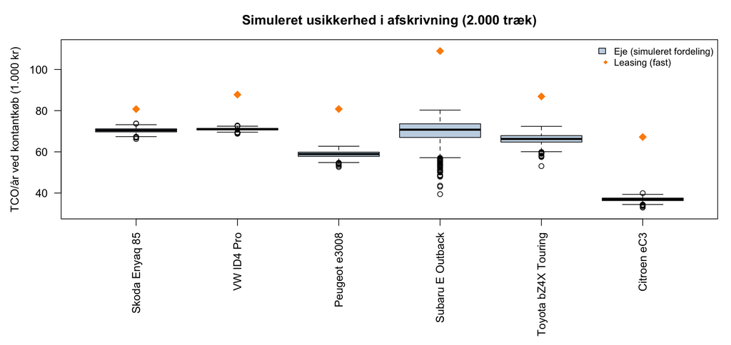

| Bil | TCO/år median | 90 %-interval | P(billigst at eje) | P(eje < leasing) |
| --- | --- | --- | --- | --- |
| Skoda Enyaq 85 | 70.449 | 68.515–72.187 | 0,0 % | 100,0 % |
| VW ID4 Pro | 71.016 | 69.975–71.891 | 0,0 % | 100,0 % |
| Peugeot e3008 | 58.916 | 56.008–61.029 | 0,0 % | 100,0 % |
| Subaru E Outback | 70.761 | 59.942–76.748 | 0,0 % | 100,0 % |
| Toyota bZ4X Touring | 66.261 | 62.129–69.904 | 0,0 % | 100,0 % |
| Citroen eC3 | 36.974 | 35.354–38.373 | 100,0 % | 100,0 % |

**Tvilling-testen (Subaru minus Toyota, kontantkøb):** median 4.397 kr/år, 90 %-interval -7.061 til 11.934 kr/år. Toyota er billigst i 76,8 % af trækkene.

## Forskel vs. alternativafkast

Alternativafkastet `k` løber ud ad x-aksen; den årlige forskel (leasing − kontant) op ad y-aksen. Over nul er leasing dyrest. Hvor kurven skærer nul, er break-even-afkastet (punkterne). De stiplede lodrette streger er vores to scenarier.

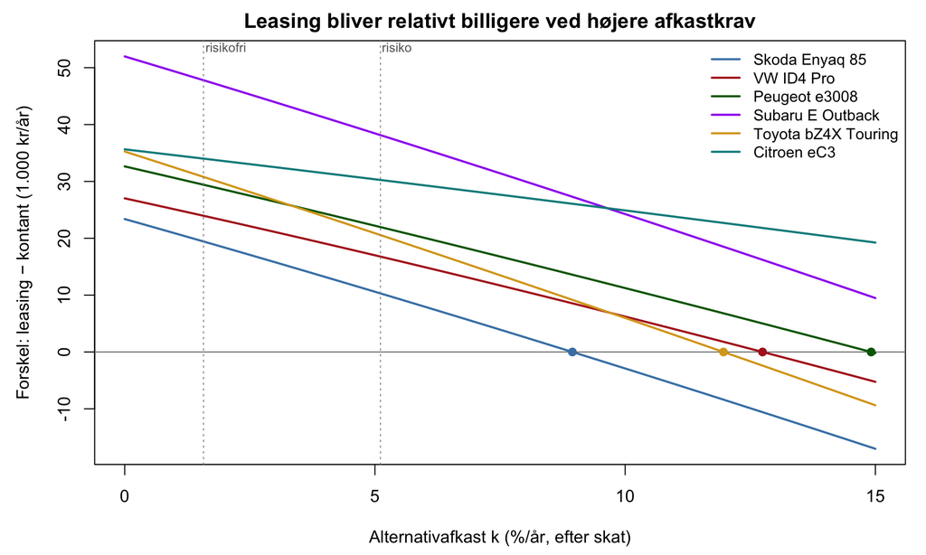

## TCO/år side om side (tre finansieringsformer)

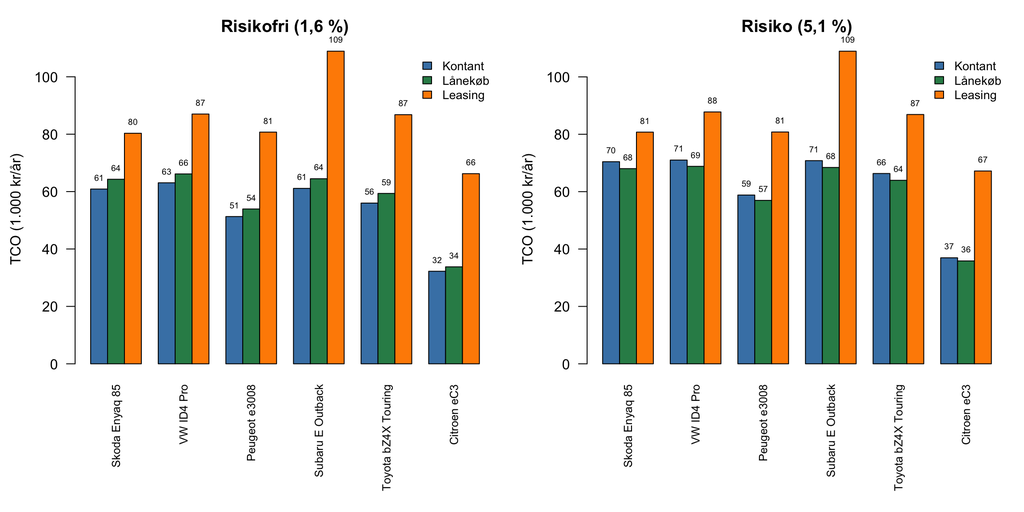

## Beslutningsvariabel vs. holdeperiode (1–15 år)

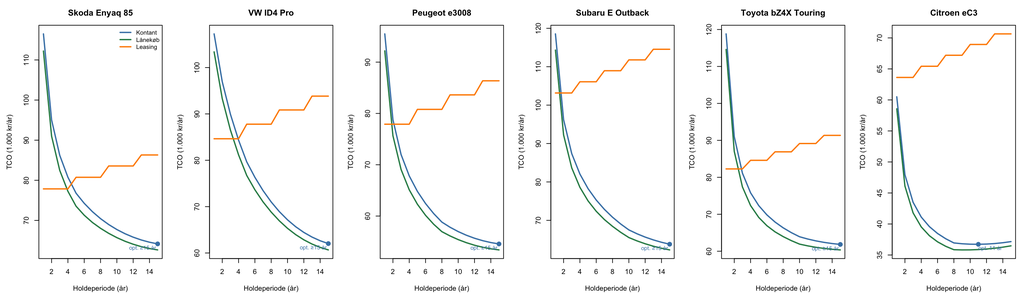

## Direkte leasingomkostning vs. kontantpris

**Venstre:** kumuleret direkte leasingbetaling (førstegangsydelser + ydelser + gebyrer + overkørte km) for hver holdeperiode. De stiplede vandrette linjer er hver bils kontantpris — hvor kurven krydser, har du betalt bilens fulde pris i ren leasing. **Højre:** samme direkte leasingomkostning pr. år delt med kontantprisen (leasingfaktor) — falder, efterhånden som førstegangsydelsen fordeles på flere år.

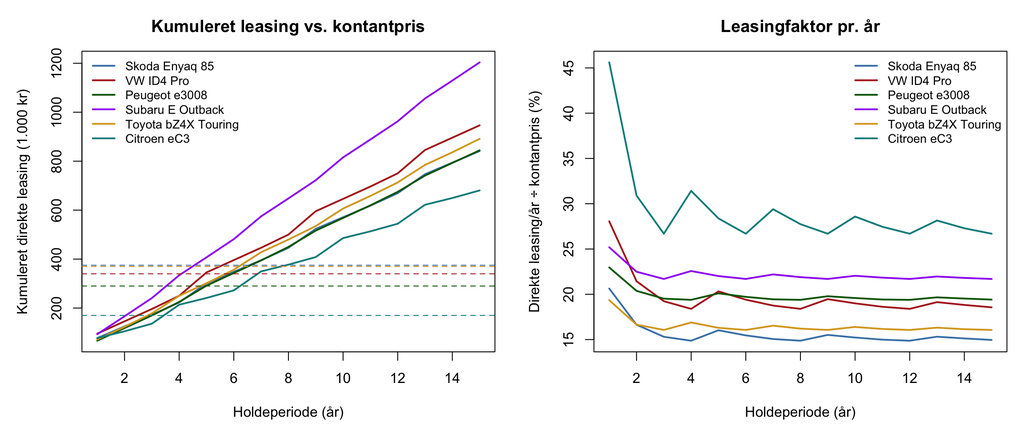

## Værditab: køb vs. leasing — hvornår krydser det?

Som ejer bærer du bilens **værditab**; som leasingtager betaler du en tilsyneladende **konstant** årlig sats (leasingfaktoren, 14,9 %–26,7 % af prisen). Men værditabet ved køb er *stejlt det første år* (20,0 % — registreringsafgift, moms og nybilspræmie fordamper) og **aftagende** derefter. De to kurver må derfor krydse hinanden.

**Øverste række:** årligt værditab (ejer, aftagende) mod årlig leasingbetaling (flad). De krydser typisk mellem år 1 og 2 — kun det første år taber ejeren mere værdi, end leasing koster. **Nederste række:** kumuleret — hvor leasing-linjen skærer ejerens værditab (●) er **break-even**: holder du bilen længere, har du tabt mindre værdi ved at eje, end du havde betalt i leasing.

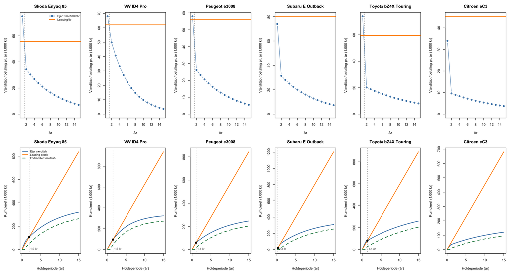

Bemærk: dette er en ren **værditabs-linse** — den ser bort fra alternativomkostning, drift og at leasing *inkluderer* service og fjerner restværdirisiko. Den fulde beslutning står i TCO-tabellen ovenfor; her isolerer vi, hvem der taber mest værdi.

## Hvor meget betyder ekstra km?

Kørslen løber ud ad x-aksen. **Kontant** (stiplet) påvirkes kun svagt — via el. **Leasing** (fuldt optrukket) har et **knæk** ved kontraktens inkluderede km (lodret streg): derover koster hver km ekstra 1 kr (jf. `Leasing_ekstra_km`), så kurven stiger stejlt. Beregnet ved risikobehæftet afkast.

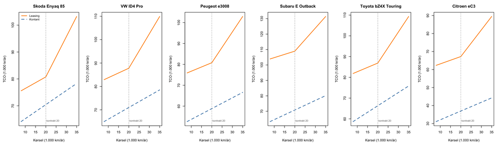

## Vedligehold: det kendte og det ukendte

Vedligehold er delt i to poster, fordi de er kendt med vidt forskellig sikkerhed:

- **Planlagt service** er *km-drevet* og prissat — eftersyn med fast interval, skiftevis et lille og et stort. Kører du dobbelt så langt, kommer du til service dobbelt så tit. For **Toyota og Subaru er priserne indhentede tilbud**; de øvrige er skøn.
- **Uplanlagte reparationer** er *alders-drevne* og rammer først efter fabriksgarantien. Det er den store ukendte — og derfor den, vi laver følsomhedsanalyse på nedenfor.

### Planlagt service — hvad et eftersyn faktisk koster

Prisen pr. besøg er middelværdien af et lille og et stort eftersyn (de veksler), plus transport til værkstedet. Ved 20.000 km/år giver intervallet antallet af besøg:

| Bil | Interval (km) | Lille (kr) | Stor (kr) | Transport (kr) | Snit pr. besøg (kr) | Besøg/år | Service (kr/år) | Kilde |
| --- | --- | --- | --- | --- | --- | --- | --- | --- |
| Skoda Enyaq 85 | 30.000 | 2.200 | 3.100 | 0 | 2.650 | 0,67 | 1.767 | skøn |
| VW ID4 Pro | 30.000 | 2.200 | 3.100 | 0 | 2.650 | 0,67 | 1.767 | skøn |
| Peugeot e3008 | 25.000 | 2.100 | 3.000 | 0 | 2.550 | 0,80 | 2.040 | skøn |
| Subaru E Outback | 15.000 | 2.411 | 3.367 | 0 | 2.889 | 1,33 | 3.852 | sourced |
| Toyota bZ4X Touring | 15.000 | 2.495 | 3.495 | 100 | 3.095 | 1,33 | 4.127 | sourced |
| Citroen eC3 | 25.000 | 1.600 | 2.300 | 0 | 1.950 | 0,80 | 1.560 | skøn |

Bemærk spredningen: Toyota og Subaru skal til eftersyn **hver 15.000 km**, mens VW/Škoda er antaget til 30.000 km. Ved 20.000 km/år er det forskellen mellem ~1,3 og ~0,7 besøg om året — altså næsten en fordobling af serviceudgiften, som den tidligere flade antagelse på 2.000 kr/år helt skjulte.

### Uplanlagte reparationer — hvor følsom er beslutningen?

Reparationer efter garanti er den mest usikre antagelse — og rammer *kun* eje, ikke leasing. Her løber det årlige reparationsniveau (år 1 efter garanti) ud ad x-aksen; den stiplede lodrette streg er vores kalibrering (4.000 kr). Alt beregnet ved risikobehæftet afkast (5,1 %).

**Øverste række:** TCO/år når du sælger på det *optimale* tidspunkt — kontant/lån stiger kun langsomt, fordi den optimale ejertid selv trækker sig sammen. **Nederste række:** netop den optimale ejertid — jo dyrere reparationer, jo tidligere bør du sælge, mod garantigrænsen (stiplet vandret). Pointen: en fornuftig ejer *tilpasser* holdeperioden, så eje forbliver billigere end leasing selv ved høje reparationsudgifter.

[figure not shown]

Bemærk søgt ejertid 1–20 år (derfor loftet ved 20). Er leasingprisen høj nok (fx Peugeot), når eje aldrig op på leasing inden for realistiske reparationsniveauer — den optimale reaktion er at sælge tidligere, ikke at lease.

## Metode og forbehold

**Regnemetode.** Betalinger lægges på en årlig tidslinje, diskonteres med `k`, summeres til NPV og omregnes til ækvivalent årlig omkostning `k/(1−(1+k)^−n)`. Alternativomkostningen ligger *i* diskonteringen — ingen separat kapitalrente (dobbelttælling). Beregningen er **nominel**: fremtidige omkostninger inflateres med 2,0 %/år og diskonteres med den nominelle rente.

**Nominel = real — og hvad renten *er*.** Vi diskonterer med **alternativafkastet** (1,6 % eller 5,1 %) — dét, de bundne penge ellers kunne have tjent — *ikke* med inflationen. At regne nominelt (inflaterede beløb ÷ nominel rente) giver *præcis* samme nutidsværdi som at regne realt (dagens kroner ÷ realrenten `(1+k)/(1+π)−1`); modellen regner altså reelt i realrente, blot udtrykt i nominelle kroner. At en krone køber mindre om nogle år fanges af, at **realrenten er lav — for risikofri endda negativ** (se antagelserne): kapital bundet risikofrit taber købekraft, selv om det nominelle afkast er positivt. Inflationen lægges bevidst *ikke* oveni renten — den nominelle rente indeholder den allerede, så det ville dobbelttælle.

- **Kontant/lån** ejer bilen: fuld pris (eller udbetaling + annuitetslån med rentefradrag) betales, drift løber årligt, restværdien modtages ved salg. Restgæld ud over holdeperioden indfries ved salg. Låneydelsen er fast nominel. **Vedligehold er delt i to poster med hver sin driver:** planlagt service er *km-drevet* (eftersyn hver 15.000–30.000 km, skiftevis lille og stort eftersyn), mens uplanlagte reparationer er *alders-drevet* og først rammer efter fabriksgarantien.
- **Leasing** modelleres over holdeperioden (rundet op til hele kontrakter à 48 mdr for Škoda/VW/Peugeot, 36 mdr for Subaru, Toyota og ë-C3). Ydelser er faste nominelt *inden for* en kontrakt, men hver ny gen-leasing prissættes til det inflaterede niveau. Hver cyklus er en ny bil. Service er inkluderet; dæk, forsikring, CO₂-ejerafgift, brændstof og overkørte km betales af leasingtageren.

**Vigtige forbehold — tallene er eksempler, ikke et konkret tilbud:**

- **Leasingtal** er estimater skaleret fra 2026-kampagner (headline 10.000–15.000 km/år) til 20.000 km/år; Subaru fra glad.dk (5.695 kr/md @ 15.000 km, 36 mdr); ë-C3 skaleret fra 1.495 kr/md @ 10.000 km (+400 kr pr. 5.000 km → 2.295 @ 20.000). **Lånevilkår** (20,0 % / 5,5 % / 7 år), **drift** (forsikring, dæk, ejerafgift) og **post-garanti-reparationer** (4.000 kr/år stigende 13,0 %) er skøn — sidstnævnte styrer den optimale ejertid og bør kalibreres mod egne tal. Ret alt i leasing_vs_kontant_input.csv og kontrolpanelet.
- **Service er nu km-drevet med rigtige værkstedspriser.** **Toyota og Subaru er sourcede:** Toyota Køge prisberegner (2. sep. 2026) og et autoriseret Subaru-værksted i Danmark (skriftligt tilbud 3. sep. 2026, e-Outback 280 kW, inkl. moms; værkstedet navngives ikke, da tilbuddet er udstedt til en privatperson og ikke offentliggjort som prisliste) — begge med eftersyn hver 15.000 km, skiftevis lille og stort. Subaru-tilbuddet rækker kun til 75.000 km/5 år; derefter holdes priserne flade, hvilket er en **ekstrapolation**. Toyota bærer 40 km ekstra transport pr. besøg à 2,5 kr/km. **De øvrige fire biler er skøn** — både pris og interval (VW/Škoda antaget 30.000 km, Stellantis 25.000 km) er sat ud fra segment og mærkepraksis, ikke indhentede tilbud. Kilden pr. bil står i input-tabellen (`Service_kilde`).
- **Afskrivning** = stejlt 1. år (20,0 %, fast skøn) og derefter din mærke-/el-specifikke brugtmarkedsrate. Første-års-klippen og forhandlerrabatten (15,0 %) er runde skøn — de driver værditabs-break-even og bør kalibreres mod konkrete indkøbs-/gensalgspriser. **Subaru mangler el-data** (for få brugte) → manuel 10,6 %-rate; meget usikker, så se afskrivnings-følsomhedsplottet for hvordan konklusionen afhænger af den. **ë-C3** bruger Citroën-mærkets el-rate (7,1 %) — lav, men baseret på ældre Citroën-elbiler; en ny budget-elbil kan falde hurtigere, så tjek følsomhedsplottet. **⚠️ Vigtig inkonsistens mellem tvillingerne:** Toyota bZ4X Touring og Subaru e-Outback er ifølge garantianalysen *identisk hardware*, og de koster næsten det samme (369.990 vs 369.900 kr). Alligevel giver modellen dem 6,8 % mod 10,6 % i årlig afskrivning — udelukkende fordi Toyota *har* empiriske brugtdata og Subaru ikke har. Den ene forskel forklarer stort set hele forskellen i deres TCO/år og er en **artefakt af manglende data, ikke evidens**. Enten bør Subarus rate sættes tæt på Toyotas, eller også bør de to sammenlignes med afskrivning slået fra. Fordi raten er så usikker, kan **hele værditabet slås fra** med `MED_AFSKRIVNING <- FALSE` (restværdi = fuld kontantpris) — en nedre grænse for ejeromkostningen. De to værditab-plots viser altid afskrivning uanset switchen.
- **Inflation** (2,0 %/år): løbende omkostninger vokser med inflationen, og hver ny leasingkontrakt prissættes inflateret — så inflation gør **leasing relativt dyrere** over tid. Fast-forrentede **låneydelser holdes nominelt konstante**. Afkastrenterne er nominelle efter skat (aktie 27 %, rente 37 %, rentefradrag 33 %); de reale renter (efter inflation) står i antagelserne. Bemærk: lån-vs-kontant-forskellen er upåvirket af inflation, da både lånerente og diskonteringsrente er nominelle og faste.

Knit: `rmarkdown::render("leasing_vs_kontant.Rmd")`. Ny bil = ny kolonne i leasing_vs_kontant_input.csv. ```